# 01 Download an OS OpenData Product

Using the `osdatahub` R package to programmatically download an OS OpenData product.

## OS Data Hub

The OS Data Hub is the new data portal to access Ordnance Survey (OS) data. Data can be downloaded through a user interface or programmatically via a series of APIs enabling direct integration with software applications.

The OS Data Hub [Public Sector Plan](https://www.ordnancesurvey.co.uk/business-government/public-sector-geospatial-agreement/data-hub-for-public-sector) provides [PSGA members](https://www.ordnancesurvey.co.uk/business-government/sectors/public-sector) with unlimited access to OS OpenData and OS Premium data available under the PSGA via API or download.

## OS Downloads API

The [OS Downloads API](https://osdatahub.os.uk/docs/downloads/overview) is a service that lets you automate the discovery and download of OS OpenData and Premium data products.

## `osdatahub`

`osdatahub` is a new R package from OS that makes it easier to interact with OS data via the OS Data Hub APIs. Note: the `osdatahub` package for R has not yet been released publicly. It should hopefully be available summer 2023.

## OS Open Greenspace

The OS OpenData product [OS Open Greenspace](https://www.ordnancesurvey.co.uk/business-government/products/open-map-greenspace) depicts the location and extent of spaces such as parks and sports facilities that are likely to be accessible to the public. Where appropriate, it also includes Access Points to show how people get into these sites. Its primary purpose is to enable members of the public to find and access greenspaces near them for exercise and recreation.

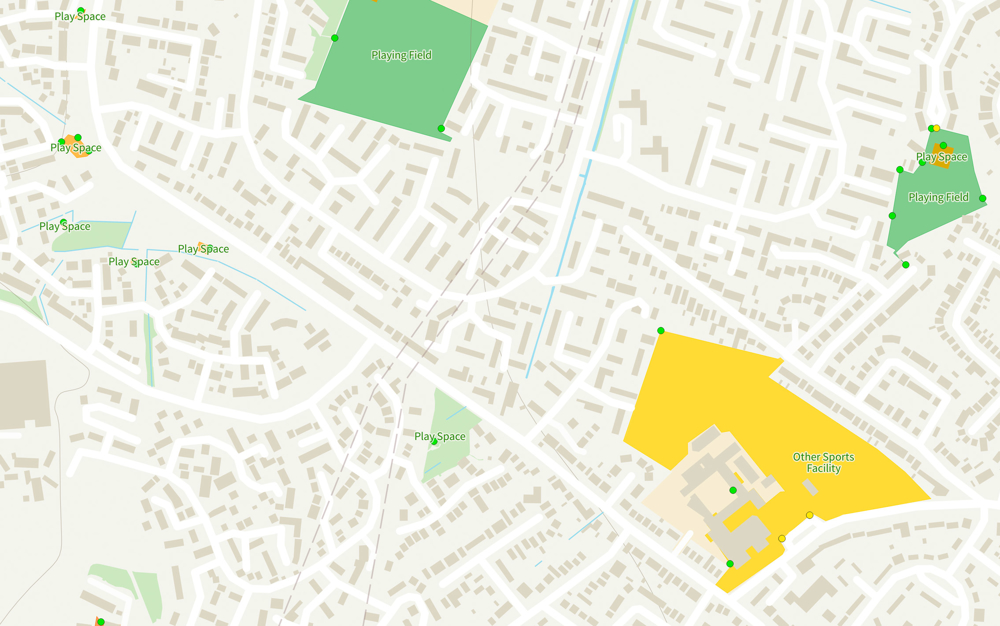

Example of the OS Open Greenspace product.

```r
library(osdatahub)
```

```r
# Create a data frame from a list of all available OS OpenData products
df <- list_os_opendata()

# Return data frame
df
```

|  | id | name | description | version | url |
| --- | --- | --- | --- | --- | --- |
| 1 | 250kScaleColourRaster | 1:250 000 Scale Colour Raster™ | Get the regional view of towns and villages, roads and places of interest. | 2023-06 | https://api.os.uk/downloads/v1/products/250kScaleColourRaster |
| 2 | BoundaryLine | Boundary-Line™ | From Euro constituencies to council wards, Boundary-Line™ maps every administrative boundary in detail for you. | 2023-05 | https://api.os.uk/downloads/v1/products/BoundaryLine |
| 3 | BuiltUpAreas | OS Open Built Up Areas | OS Open Built Up Areas represents the built-up areas of Great Britain equal to or greater than 200,000m² or 20 hectares and they include unique names, alternative language names and GSS codes. | 2022-12 | https://api.os.uk/downloads/v1/products/BuiltUpAreas |
| 4 | CodePointOpen | Code-Point® Open | Free and open postcode location data. Can be used for geographical analysis, simple route planning, asset management and much more. | 2023-05 | https://api.os.uk/downloads/v1/products/CodePointOpen |
| 5 | GBOverviewMaps | GB Overview Maps | Our simplest maps of the British Isles. | 2014-11 | https://api.os.uk/downloads/v1/products/GBOverviewMaps |
| 6 | LIDS | OS Open Linked Identifiers | A comprehensive dataset of cross-referenced identifiers, between various OS data products. | 2023-05 | https://api.os.uk/downloads/v1/products/LIDS |
| 7 | MiniScale | MiniScale® | A simple overview map of Great Britain. | 2023-01 | https://api.os.uk/downloads/v1/products/MiniScale |
| 8 | OpenGreenspace | OS Open Greenspace | Covering a range of greenspaces in urban and rural areas including playing fields, sports’ facilities, play areas and allotments. | 2023-04 | https://api.os.uk/downloads/v1/products/OpenGreenspace |
| 9 | OpenMapLocal | OS OpenMap - Local | Map, visualise and truly understand your data at street level. | 2023-04 | https://api.os.uk/downloads/v1/products/OpenMapLocal |
| 10 | OpenNames | OS Open Names | A comprehensive dataset of place names, roads numbers and postcodes for Great Britain. | 2023-04 | https://api.os.uk/downloads/v1/products/OpenNames |

[output cut: 8 more lines]

```r
# Specify an OS OpenData product by 'id'

product <- 'OpenGreenspace'

# Create a data frame with the download options for a given product
df_osog <- list_os_opendata(product)

# Return data frame
df_osog
```

|  | md5 | size | url | format | area | fileName | subformat |
| --- | --- | --- | --- | --- | --- | --- | --- |
| 1 | 2dd054c589f4545a8edae64818647e4c | 6855 | https://api.os.uk/downloads/v1/products/OpenGreenspace/downloads?area=HP&format=ESRI%C2%AE+Shapefile&redirect | ESRI® Shapefile | HP | opgrsp_essh_hp.zip | NA |
| 2 | 9c6878319e258466764941dc4f5a12aa | 4101 | https://api.os.uk/downloads/v1/products/OpenGreenspace/downloads?area=HT&format=ESRI%C2%AE+Shapefile&redirect | ESRI® Shapefile | HT | opgrsp_essh_ht.zip | NA |
| 3 | f90b942764f6b3c6c0dcdb5eb9eaa78b | 32737 | https://api.os.uk/downloads/v1/products/OpenGreenspace/downloads?area=HU&format=ESRI%C2%AE+Shapefile&redirect | ESRI® Shapefile | HU | opgrsp_essh_hu.zip | NA |
| 4 | 731c20ba654c39b352b6f8fb6a06668d | 25314 | https://api.os.uk/downloads/v1/products/OpenGreenspace/downloads?area=HY&format=ESRI%C2%AE+Shapefile&redirect | ESRI® Shapefile | HY | opgrsp_essh_hy.zip | NA |
| 5 | 9fb4b3ac9854c0de80b8cffc550d4fa2 | 4327 | https://api.os.uk/downloads/v1/products/OpenGreenspace/downloads?area=HZ&format=ESRI%C2%AE+Shapefile&redirect | ESRI® Shapefile | HZ | opgrsp_essh_hz.zip | NA |
| 6 | 5ab724cb2937ef3bb16e67c452dd9c6a | 2686 | https://api.os.uk/downloads/v1/products/OpenGreenspace/downloads?area=NA&format=ESRI%C2%AE+Shapefile&redirect | ESRI® Shapefile | NA | opgrsp_essh_na.zip | NA |
| 7 | 60825cd668b19119287d09c518aae50d | 31044 | https://api.os.uk/downloads/v1/products/OpenGreenspace/downloads?area=NB&format=ESRI%C2%AE+Shapefile&redirect | ESRI® Shapefile | NB | opgrsp_essh_nb.zip | NA |
| 8 | 06ed353aa651a85be83a7cb2ffdab060 | 27760 | https://api.os.uk/downloads/v1/products/OpenGreenspace/downloads?area=NC&format=ESRI%C2%AE+Shapefile&redirect | ESRI® Shapefile | NC | opgrsp_essh_nc.zip | NA |
| 9 | 718803b8d13b7ef6f87565878740badd | 35397 | https://api.os.uk/downloads/v1/products/OpenGreenspace/downloads?area=ND&format=ESRI%C2%AE+Shapefile&redirect | ESRI® Shapefile | ND | opgrsp_essh_nd.zip | NA |
| 10 | e5982dd7c4cb524da80bf941b9aaab0e | 16819 | https://api.os.uk/downloads/v1/products/OpenGreenspace/downloads?area=NF&format=ESRI%C2%AE+Shapefile&redirect | ESRI® Shapefile | NF | opgrsp_essh_nf.zip | NA |

[output cut: 98 more lines]

```r
# Subset data frame rows where the 'area' column is equal to 'GB'
df_osog[df_osog$area == 'GB', ]
```

|  | md5 | size | url | format | area | fileName | subformat |
| --- | --- | --- | --- | --- | --- | --- | --- |
| 105 | 864ad8b3b26a12dc532cece689c86a10 | 33953674 | https://api.os.uk/downloads/v1/products/OpenGreenspace/downloads?area=GB&format=ESRI%C2%AE+Shapefile&redirect | ESRI® Shapefile | GB | opgrsp_essh_gb.zip | NA |
| 106 | 89a62eba6fa7ce1b3eb97fff80d72b54 | 34228810 | https://api.os.uk/downloads/v1/products/OpenGreenspace/downloads?area=GB&format=GML&subformat=3&redirect | GML | GB | opgrsp_gml3_gb.zip | 3 |
| 107 | c67ad8401c9e30c8164ecd41bcaad6a8 | 50623366 | https://api.os.uk/downloads/v1/products/OpenGreenspace/downloads?area=GB&format=GeoPackage&redirect | GeoPackage | GB | opgrsp_gpkg_gb.zip | NA |
| 108 | 14f208dec70514a3e62b67e7dc773eb7 | 76548833 | https://api.os.uk/downloads/v1/products/OpenGreenspace/downloads?area=GB&format=Vector+Tiles&subformat=%28MBTiles%29&redirect | Vector Tiles | GB | opgrsp_mbtiles_gb.zip | (MBTiles) |

```r
# Download OS OpenData product by search criteria
download_os_opendata(product = 'OpenGreenSpace',
                     file_format = 'GeoPackage',
                     area = 'GB',
                     output_dir = tempdir())
```